# Spatial models in NIMBLE

NIMBLE workshop, CEFE/CNRS, Montpellier, France

NIMBLE Development Team

November 2025

# Spatial models (also useful as non-parametric regression components)

Methods for spatial models in `nimble` include:

- Conditional auto-regressive (CAR) models
- Gaussian process models defined by correlation decaying with distance.
- Gaussian process models defined by spline basis functions

# Intrinsic conditional autoregressive (ICAR) models

Intuitively expressed as one-at-a-time conditionals:

$$x_i|x_{-i} \sim N\left(\frac{1}{n_i}
\sum_{j\in N_i} x_j, \frac{1}{n_i \tau}\right)$$

The prior for each $x_i$ has:

- mean: the mean of its neighbors
- variance: inversely proportional to the number of neighbors.

This seems paradoxical, but it works.

Model code:

```r
x[1:N] ~ dcar_normal(adj[1:L], weights[1:L], num[1:N],
                     tau, c, zero_mean)
```

NIMBLE’s MCMC configuration will use a special sampler that updates each `x[i]` one by one (using conditionality).

# ICAR (cont): What does ‘intrinsic’ mean?

This is an **improper prior** because it does not integrate to one.

The value of the prior doesn’t change if you shift all the $x_{i}$ values by a constant.

Thus the model implicitly includes an intercept with a flat prior.

It is usually fine to use `zero_mean=FALSE`.

This is also weird because the marginal prior variance of each $x_i$ is infinite, but it works.

(This is akin to a non-stationary (unit root) AR(1) model with $\rho = 1$:

$$x_i \sim N(\rho x_{i-1}, \sigma^2)$$

which is generally frowned upon in the time series literature. But it’s often recommended in the spatial context.)

# ICAR (cont): Neighborhood/adjacency information

Suppose we have 4 spatial locations in a square grid:

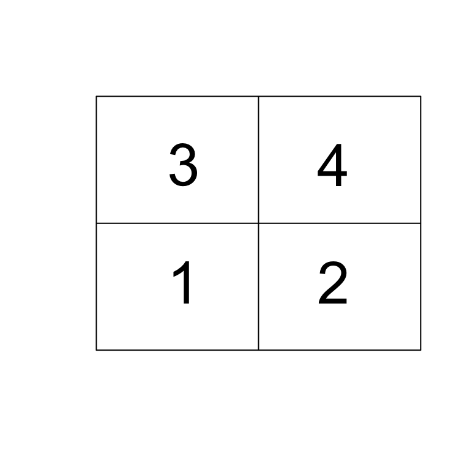

Then we would have:

```r
num <- c(2, 2, 2, 2)  # each location has two neighbors
adj <- c(2, 3,        # neighbors of loc'n 1
          1, 4,         # neighbors of loc'n 2
          1, 4,         # etc.
          2, 3)
```

There are various NIMBLE and R functions for producing `adj` and `num` from shapefiles and other geographic formats.

# ICAR (cont): Example: disease mapping

- (Classic) example: hospital admissions due to respiratory disease in 2010 from the 134 Intermediate Geographies (IG) north of the river Clyde in the Greater Glasgow and Clyde health board.
- Data available in the `CARBayesdata` package.
- Transform into neighborhood information using functions from the `spdep` package.
- We need vectors indicating
  - which regions are neighbors of which other regions (`adj`),
  - weights for each pair of neighbors (`weights`),
  - the number of neighbors for each region (`num`) (to unpack `adj` correctly).
- Modeled mean of the Poisson counts includes an offset for the expected count (e.g. population size).
- Covariate: the percentage of people defined as income-deprived in each region.

```r
library(CARBayesdata, quietly = TRUE)
library(sp, quietly = TRUE)
library(spdep, quietly = TRUE)
```

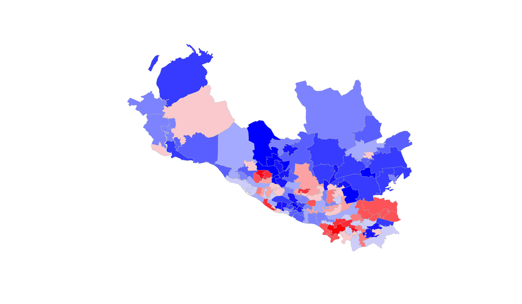

```r
library(classInt)
## data(GGHB.IG) ## apparently no longer in CARBayesdata
load('GGHB.IG.Rda')
data(respiratorydata)

respiratorydata_sp <- merge(x = GGHB.IG, y = respiratorydata, by.x = "IG",
                            by.y = "IZ", all.x = FALSE)
respiratorydata_sp <- spTransform(respiratorydata_sp,
                                  CRS("+proj=longlat +datum=WGS84 +no_defs"))

if(FALSE) {
  # This will produce an image on top of an OpenStreetMap webpage}
  library(leaflet)
  colors <- colorNumeric(palette = "YlOrRd", domain = respiratorydata_sp@data$SMR)
  map2 <- leaflet(data=respiratorydata_sp) %>%
    addPolygons(fillColor = ~colors(SMR), color="", weight=1,
                fillOpacity = 0.7) %>%
    addLegend(pal = colors, values = respiratorydata_sp@data$SMR, opacity = 1,
              title="SMR") %>%
    addScaleBar(position="bottomleft")
  map2
}

# Instead, make a simple map in R
temp.colors<-function(n = 25) {
  m <- floor(n/2)
  blues <- hsv(h=.65, s=seq(1,0,length=m+1)[1:m])
  reds <- hsv(h=0, s=seq(1,0,length=m+1)[1:m])
  c(blues,if(n%%2!=0) "#FFFFFF", reds[m:1])
}

q <- classIntervals(respiratorydata_sp@data$SMR ,style = "fixed",
                    fixedBreaks=seq(0.3, 1.7, by = 0.1))
pal <- temp.colors(12)
col <- findColours(q, pal)
plot(respiratorydata_sp, col = col, border = 'grey', lwd = 0.4)
```

# ICAR (cont): Neighborhood/adjacency information

We handle the neighborhood structure here with `nb2WB` from the package `spdep`.

```r
W_nb <- poly2nb(respiratorydata_sp, row.names =  rownames(respiratorydata_sp@data))
## Determine neighborhood/adjacency information needed for neighborhood-based CAR model
nbInfo <- nb2WB(W_nb)

# A vector of indices indicating which regions are neighbors of which.
head(nbInfo$adj, n = 30)
```

```
##  [1]   2   3   5  87  91  93   1   3  91 113   1   2   5  11 113   6   7  10  98
## [20] 101 105 106   1   3   9  11  19  87  90 104
```

```r
# A vector of weights. In this case, all weights are 1.
head(nbInfo$weights)
```

```
## [1] 1 1 1 1 1 1
```

```r
# A vector of length N indicating how many neighbors each region has.
# This helps map the adj vector to each region.
nbInfo$num
```

```
##   [1]  6  4  5  7  9  5  5  5  4  7  7 11  4  4  7  5  6  5  6 10  3  8  2  4  4
##  [26]  4  2  4  4  4  5  2  4  6  3  4  5  6  7  4  6  6  8  6  6  5  6  4  3  5
##  [51]  3  6  4  5  9  7  3  4  7  6  7  7  8  5  6  4  4  6  4  5  5  7  6  6  5
##  [76]  6  5  6  6  5  6  5  5  5 10  7  6  9  4  6  7  5  5  5  7  6  4  6  5  5
## [101]  6  6  5  5  7  6  7  7  8  5  3  6 10  5  2  3  4  5  7  4  5  8  4  4  3
## [126]  8  5  1  4  4  4  7  3  2
```

Now we have the three pieces of information we need. We’re ready to use the `dcar_normal` distribution in a nimble model.

# ICAR (cont): nimble model

```r
code <- nimbleCode({
  # priors
  beta ~ dnorm(0, sd = 100)
  sigma ~ dunif(0, 100)   # prior for variance components based on Gelman (2006)
  tau <- 1 / sigma^2
  # latent process
  x[1:N] ~ dcar_normal(adj[1:L], weights[1:L], num[1:N], tau, zero_mean = 0)
  # likelihood
  for(i in 1:N) {
    lambda[i] <- expected[i] * exp(beta*z[i] + x[i])
    y[i] ~ dpois(lambda[i])
  }
})

z <- respiratorydata_sp$incomedep
z <- z - mean(z)  # center for improved MCMC performance

set.seed(1)

nregions <- nrow(respiratorydata_sp)
expected <- respiratorydata_sp$expected
y <- respiratorydata_sp$observed
constants <- list(N = nregions, L = length(nbInfo$adj),
                  adj = nbInfo$adj, weights = nbInfo$weights, num = nbInfo$num,
                  z = z, expected = expected)
data <- list(y = y)
inits <- list(beta = 0, sigma = 1, x = rnorm(nregions))

model <- nimbleModel(code, constants = constants, data = data, inits = inits)
```

```
## Defining model
```

```
## Building model
```

```
## Setting data and initial values
```

```
## Running calculate on model
##   [Note] Any error reports that follow may simply reflect missing values in model variables.
```

```
## Checking model sizes and dimensions
```

```r
cModel <- compileNimble(model)
```

```
## Compiling
##   [Note] This may take a minute.
##   [Note] Use 'showCompilerOutput = TRUE' to see C++ compilation details.
```

```r
conf <- configureMCMC(model, monitors = c('beta', 'sigma', 'x'))
```

```
## ===== Monitors =====
## thin = 1: beta, sigma, x
## ===== Samplers =====
## RW sampler (2)
##   - beta
##   - sigma
## CAR_normal sampler (1)
##   - x[1:134]
```

```r
conf$printSamplers()
```

```
## [1] RW sampler: beta
## [2] RW sampler: sigma
## [3] CAR_normal sampler: x[1:134]
```

```r
MCMC <- buildMCMC(conf)
cMCMC <- compileNimble(MCMC, project = cModel)
```

```
## Compiling
##   [Note] This may take a minute.
##   [Note] Use 'showCompilerOutput = TRUE' to see C++ compilation details.
```

```r
samples <- runMCMC(cMCMC, niter = 5000, nburnin = 1000, thin = 10)
```

```
## running chain 1...
```

```
## |-------------|-------------|-------------|-------------|
## |-------------------------------------------------------|
```

# ICAR (cont): Results

MCMC mixing looks pretty good (not always the case for spatial models).

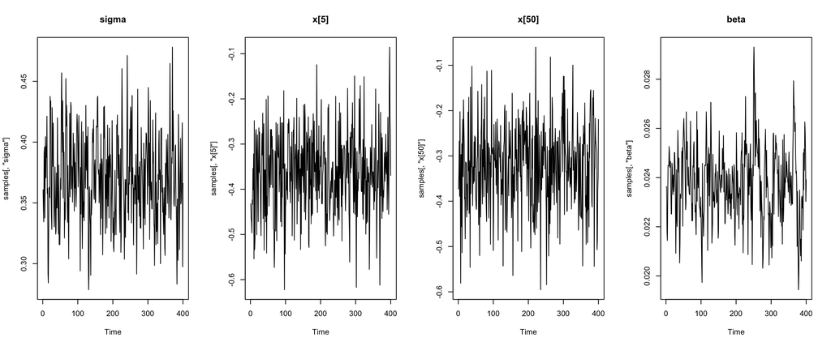

```r
par(mfrow = c(1,4))
ts.plot(samples[ , 'sigma'], main = 'sigma')
ts.plot(samples[ , 'x[5]'], main = 'x[5]')
ts.plot(samples[ , 'x[50]'], main = 'x[50]')
ts.plot(samples[ , 'beta'], main = 'beta')
```

We can look at the map of the estimated relative risks. Note the scale is very different than of the standardized mortality ratio raw values.

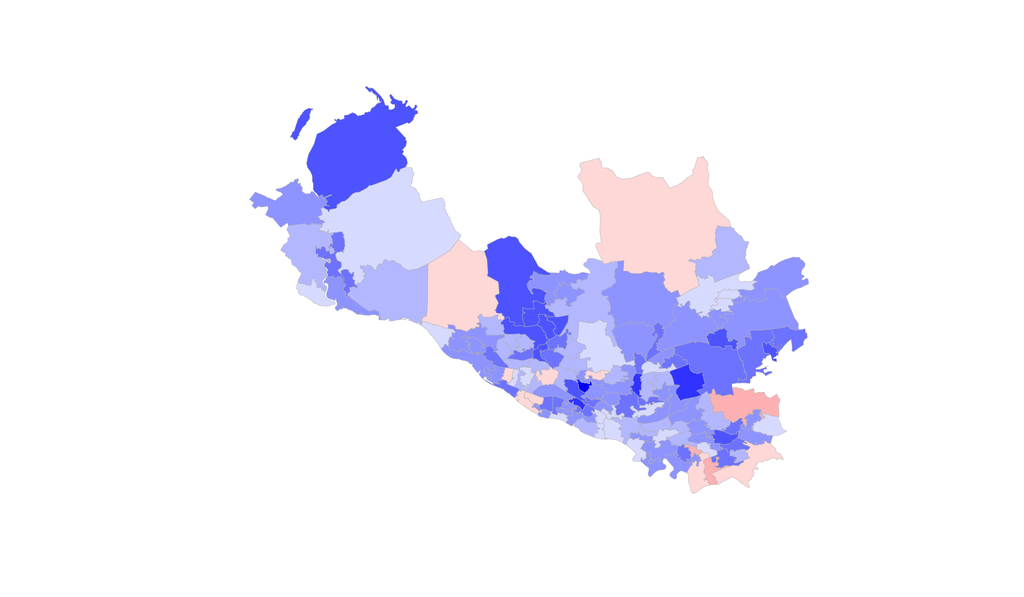

```r
xCols <- grep('^x\\[', colnames(samples))
xEstCAR <- colMeans(samples[ , xCols])

q <- classIntervals(xEstCAR,style = "fixed",fixedBreaks=seq(-0.8, 0.8, by = 0.1))
pal <- temp.colors(16)
col <- findColours(q, pal)

par(mfrow = c(1,1))
plot(respiratorydata_sp, col = col, border = 'grey', lwd = 0.4)
```

# Proper CAR model (we will not cover this)

One can avoid the improper ICAR prior by using what looks like a time series AR(1) model. Omitting any weights and with mean zero, the simplest case is:

$$x_i|x_{-i} \sim N \left(\frac{1}{n_i}
\rho \sum_{j\in N_i} x_j, \frac{1}{n_i \tau}\right)$$

The presence of $\rho$ causes the prior to be proper (under certain constraints on $\rho$).

This looks more like the usual AR(1) model with the somewhat non-intuitive property that the prior mean is a proportion of the average of the neighbors. The result is a model where the relationship of $\rho$ to the spatial correlation structure is not intuitive and even modest spatial correlation results in very large values of $\rho$.

Note: when the number of neighbors is roughly the same for all locations the Leroux model can be seen to be approximately a variation on this model.

# Gaussian processes

- Multivariate normal priors at a finite set of locations.
- Correlation between points decays with distance by some function with parameters to estimate.
- No special nimble functionality if needed.
- Sometimes used for areal data, evaluated at the centroids of the areas.
- More commonly used for continuous data or regularly-gridded data.
- For simplicity, we’ll use the example from the CAR model (above).

```r
code <- nimbleCode({
  mu0 ~ dnorm(0, sd = 100)
  sigma ~ dunif(0, 100)  # prior for variance components based on Gelman (2006)
  rho ~ dunif(0, 5)
  beta ~ dnorm(0, sd = 100)

  # latent spatial process
  mu[1:N] <- mu0*ones[1:N]
  cov[1:N, 1:N] <- sigma*sigma*exp(-dists[1:N, 1:N] / rho)
  x[1:N] ~ dmnorm(mu[1:N], cov = cov[1:N, 1:N])
  # likelihood
  for(i in 1:N) {
    lambda[i] <- expected[i] * exp(beta*z[i] + x[i])
    y[i] ~ dpois(lambda[i])
  }
})

locs <-  as.matrix(respiratorydata_sp@data[ , c('easting', 'northing')]) / 1e5
dists <- as.matrix(dist(locs))
dists <- dists / max(dists)  # normalize to max distance of 1

constants <- list(N = nregions, dists = dists, ones = rep(1, nregions),
                            z = z, expected = expected)
data <- list(y = y)
inits <- list(beta = 0, mu0 = 0, sigma = 1, rho = 0.2)

set.seed(1)

## setup initial spatially-correlated latent process values
inits_cov <- inits$sigma^2 * exp(-dists / inits$rho)
inits$x <-  t(chol(inits_cov)) %*% rnorm(nregions)
inits$x <- inits$x[ , 1]  # so can give nimble a vector rather than one-column matrix

model <- nimbleModel(code, constants = constants, data = data, inits = inits)
```

```
## Defining model
```

```
## Building model
```

```
## Setting data and initial values
```

```
## Running calculate on model
##   [Note] Any error reports that follow may simply reflect missing values in model variables.
```

```
## Checking model sizes and dimensions
```

```r
cModel <- compileNimble(model)
```

```
## Compiling
##   [Note] This may take a minute.
##   [Note] Use 'showCompilerOutput = TRUE' to see C++ compilation details.
```

# Gaussian processes (continued): Running an MCMC

In order to improve mixing, we’ll customize a tuning parameter for the block random walk (Metropolis) sampler on the latent spatial values.

```r
conf <- configureMCMC(model)
```

```
## ===== Monitors =====
## thin = 1: beta, mu0, rho, sigma
## ===== Samplers =====
## RW_block sampler (1)
##   - x[1:134]
## RW sampler (4)
##   - mu0
##   - sigma
##   - rho
##   - beta
```

```r
conf$addMonitors('x')
```

```
## thin = 1: beta, mu0, rho, sigma, x
```

```r
conf$removeSamplers('x[1:134]')
## Changing a tunable parameter in the adaptation of RW_block makes a big difference.
conf$addSampler('x[1:134]', 'RW_block', control = list(adaptFactorExponent = 0.25))
```

```
##   [Note] Assigning an RW_block sampler to nodes with very different scales can result in low MCMC efficiency.  If all nodes assigned to RW_block are not on a similar scale, we recommend providing an informed value for the "propCov" control list argument, or using the "barker" sampler instead.
```

```r
MCMC <- buildMCMC(conf)
cMCMC <- compileNimble(MCMC, project = cModel)
```

```
## Compiling
##   [Note] This may take a minute.
##   [Note] Use 'showCompilerOutput = TRUE' to see C++ compilation details.
```

```r
samples <- runMCMC(cMCMC, niter = 10000, nburnin = 5000, thin = 5)
```

```
## running chain 1...
```

```
## |-------------|-------------|-------------|-------------|
## |-------------------------------------------------------|
```

# Gaussian processes (continued): Results

MCMC mixing could be better (often the case for spatial models), but is not terrible. We’d want to run for longer.

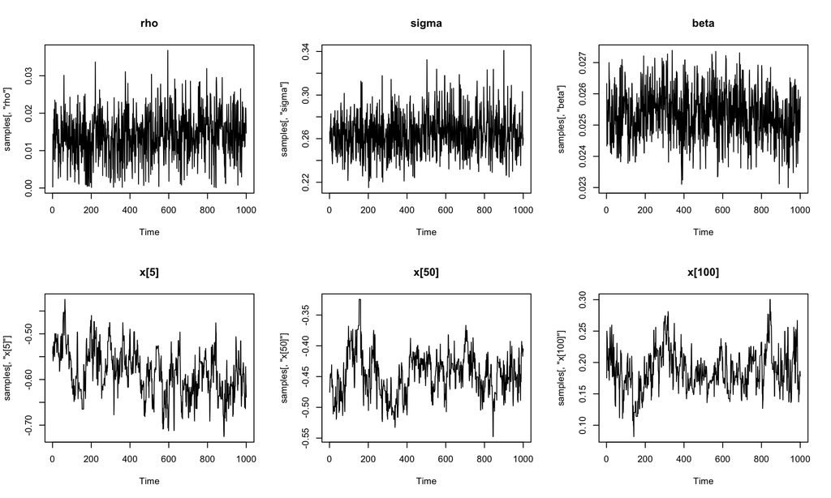

```r
par(mfrow = c(2,3))
ts.plot(samples[ , 'rho'], main = 'rho')
ts.plot(samples[ , 'sigma'], main = 'sigma')
ts.plot(samples[ , 'beta'], main = 'beta')
ts.plot(samples[ , 'x[5]'], main = 'x[5]')
ts.plot(samples[ , 'x[50]'], main = 'x[50]')
ts.plot(samples[ , 'x[100]'], main = 'x[100]')
```

We can look at the map of the estimated relative risks. Note the scale is very different than of the standardized mortality ratio raw values.

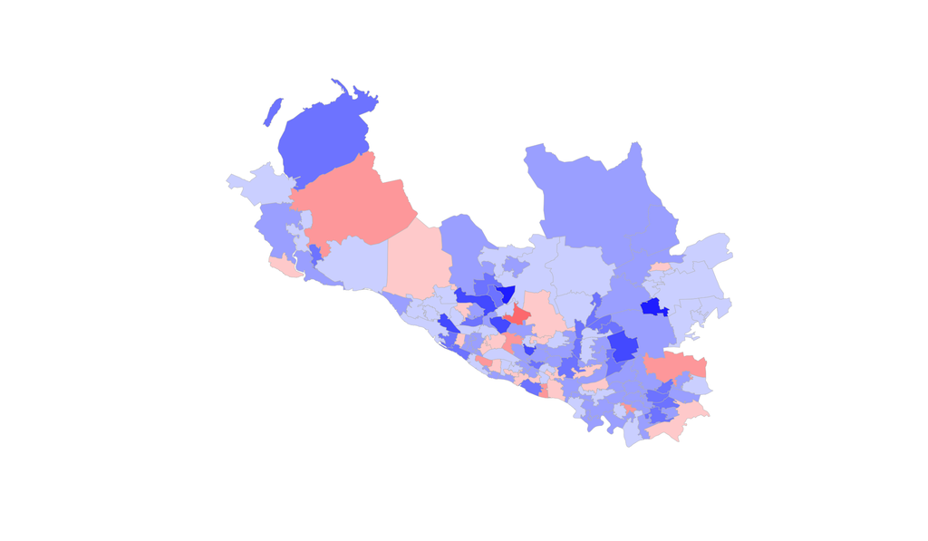

```r
xCols <- grep('^x\\[', colnames(samples))
xEstGP <- colMeans(samples[ , xCols])

q <- classIntervals(xEstGP, style = "fixed", fixedBreaks=seq(-1.2, 1.2, by = 0.2))
pal <- temp.colors(12)
col <- findColours(q, pal)

par(mfrow = c(1,1))
plot(respiratorydata_sp, col = col, border = 'grey', lwd = 0.4)
```

# Large spatial models and spatial nonstationarity

The `BayesNSGP` package has functionality for fitting such models efficiently based on recent advances in the literature.

# Splines (for spatial models or other nonparametric regression)

- Another kind of Gaussian process.
- `mgcv` is a major spline/GAM package and has functions to set up pieces for use in JAGS or NIMBLE. `mgcv` can handle all sorts of sophisticated smoothing problems, including:
  - tensor products of space and time or of different covariates
  - cyclic splines (e.g., for seasonality, diurnal behavior)
  - monotonicity and other shape constraints
  - boundary effects

For example, Stoner and Economou (2020; Computational Statistics and Data Analysis; https://arxiv.org/abs/1906.03846) used mgcv-based spline terms in a NIMBLE model for precipitation, handling seasonality with cyclic splines.

# Splines (cont): setup from `mgcv`

- (Technical: The spline penalty matrix serves as the inverse correlation matrix for the prior. The spline smoothing parameter is a variance or variance ratio.)

$$x = B \beta$$

$$\beta \sim \mbox{MVN}(0, \mbox{prec} =
Q)$$

- `B` are spline basis function evaluations (obtained from `mgcv`)
- `beta` is a coefficient vector to be estimated
- `Q` is the spline penalty matrix (obtained from `mgcv`) times a variance parameter to be estimated.
- Actually the `Q` provided by `mgcv` includes some unpenalized dimensions (constant and linear) so it needs to be split into two pieces (penalized and unpenalized).

```r
K <- 40 # number of spline basis functions
# fit a simple GAM to get a sense for number of basis functions; K = 40 might be too small...
if(FALSE) {
  mod <- gam(y ~ log(expected) + z + s(locs, k = K), family = 'poisson')
  summary(mod)
  fit <- predict(mod, type = 'terms')[,3]
}

# ignore z to get basis info, but that may affect initial values.
out <- mgcv::jagam(y ~ log(expected) + s(locs, k = K) -1, family = 'poisson',
                   na.action = na.pass, file = 'blank.jags')
B <- out$jags.data$X[ , -1]
K <- ncol(B)   # actually only 39 basis functions
## two components of precision matrix to ensure propriety
## of prior on coeffs (see Wood (2016) J Statistical Software)
Q1 <- out$jags.data$S1[ , 1:K]
Q2 <- out$jags.data$S1[ , (K+1):(2*K)]
```

# Splines (cont): Setting up the model

We’ll stick with a simple spatial model (which means this could have simply been fit using `mgcv::gam`):

```r
codeS <- nimbleCode({
  mu0 ~ dflat()
  beta_z ~ dnorm(0, sd = 100)
  for(i in 1:2)
    lambda[i]  ~ dgamma(.05, .005)  # based on jagam defaults

  # latent process is product of (known) spline basis and (unknown) coefficients
  # two components to ensure propriety of prior on coeffs
  prec[1:K, 1:K] <- lambda[1] * Q1[1:K, 1:K] + lambda[2] * Q2[1:K, 1:K]
  beta_x[1:K] ~ dmnorm(zeros[1:K], prec[1:K, 1:K])
  x[1:N] <-  (B[1:N, 1:K] %*% beta_x[1:K])[,1]

  # likelihood
  for(i in 1:N) {
    mu[i] <- expected[i] * exp(mu0 + beta_z*z[i] + x[i])
    y[i] ~ dpois(mu[i])
  }
})

constantsS <- list(Q1 = Q1, Q2 = Q2, B = B, K = K, N = nregions, z = z, zeros = rep(0, K),
                            expected = expected)
dataS <- list(y = y)
initsS <- list(beta_z = 0)
## Use inits from jagam, but note that jagam call did not use 'z' or have an intercept
initsS$beta_x <-  out$jags.ini$b[2:(K+1)]
initsS$mu0 <- 0
initsS$lambda <- out$jags.ini$lambda

set.seed(1)
modelS <- nimbleModel(codeS, constants = constantsS, data = dataS, inits = initsS)
```

```
## Defining model
```

```
## Building model
```

```
## Setting data and initial values
```

```
## Running calculate on model
##   [Note] Any error reports that follow may simply reflect missing values in model variables.
```

```
## Checking model sizes and dimensions
```

```r
cModelS <- compileNimble(modelS)
```

```
## Compiling
##   [Note] This may take a minute.
##   [Note] Use 'showCompilerOutput = TRUE' to see C++ compilation details.
```

# Splines (cont): Running an MCMC

```r
confS <- configureMCMC(modelS)
```

```
## ===== Monitors =====
## thin = 1: beta_z, lambda, mu0
## ===== Samplers =====
## RW_block sampler (1)
##   - beta_x[1:39]
## RW sampler (4)
##   - mu0
##   - beta_z
##   - lambda[]  (2 elements)
```

```r
confS$removeSamplers('beta_x[1:39]')
# Using non-default value of 0.25 for a tuning parameter of the adaptive block sampler
# helps a lot compared to default NIMBLE or to JAGS
confS$addSampler('beta_x[1:39]', 'RW_block', control = list(adaptFactorExponent = 0.25))
```

```
##   [Note] Assigning an RW_block sampler to nodes with very different scales can result in low MCMC efficiency.  If all nodes assigned to RW_block are not on a similar scale, we recommend providing an informed value for the "propCov" control list argument, or using the "barker" sampler instead.
```

```r
confS$addMonitors('x', 'beta_x')
```

```
## thin = 1: beta_x, beta_z, lambda, mu0, x
```

```r
mcmcS <- buildMCMC(confS)
cmcmcS <- compileNimble(mcmcS, project = cModelS)
```

```
## Compiling
##   [Note] This may take a minute.
##   [Note] Use 'showCompilerOutput = TRUE' to see C++ compilation details.
```

```r
samplesS <- runMCMC(cmcmcS, niter = 100000, nburnin = 20000, thin = 80)
```

```
## running chain 1...
```

```
## |-------------|-------------|-------------|-------------|
## |-------------------------------------------------------|
```

# Splines (cont): Results

Mixing is decent (though that was a pretty long run). One could explore other sampling strategies.

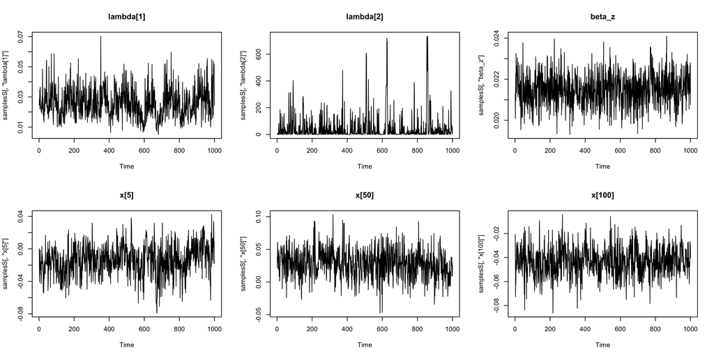

```r
par(mfrow = c(2,3))
ts.plot(samplesS[ , 'lambda[1]'], main = 'lambda[1]')
ts.plot(samplesS[ , 'lambda[2]'], main = 'lambda[2]')
ts.plot(samplesS[ , 'beta_z'], main = 'beta_z')
ts.plot(samplesS[ , 'x[5]'], main = 'x[5]')
ts.plot(samplesS[ , 'x[50]'], main = 'x[50]')
ts.plot(samplesS[ , 'x[100]'], main = 'x[100]')
```

Here are the spatial estimates. Pretty different than the CAR or GP results. We might want to explore larger values of K.

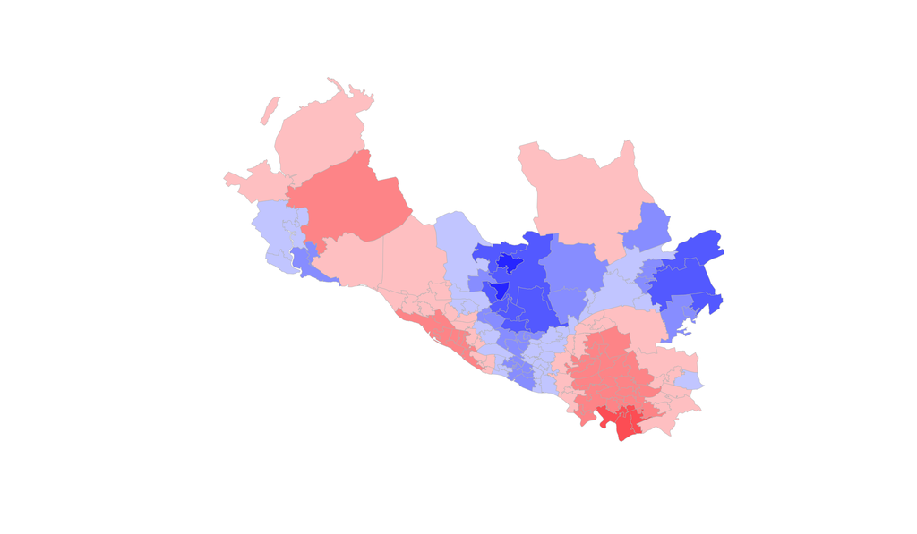

```r
xCols <- grep('^x\\[', colnames(samplesS))
xEstSpl <- colMeans(samplesS[ , xCols])

q <- classIntervals(xEstSpl, style = "fixed", fixedBreaks=seq(-0.2, 0.2, by = 0.04))
pal <- temp.colors(10)
col <- findColours(q, pal)
par(mfrow = c(1,1))
plot(respiratorydata_sp, col = col, border = 'grey', lwd = 0.4)
```